# RMSC5102 2020S A Question on Discrete Uniform

LEUNG Man Fung, Heman

# Question

Can we use continuous version of inverse transform for discrete uniform random variable?

# Answer

It is not appropriate in terms of algorithm. Below is an explanation:

To use continuous version of inverse transform, note that the cdf of discrete uniform is $F(x) = x/m$ for $x=1,\ldots,m$. Set $u = F(x)$, we have
$$x = um \implies F^{-1}(u) = um?$$
There are at least two problems here:
1) As $F(x)$ is only defined at $x=1,...,m$, the inverse function $F^{-1}(u)$ is actually not well-defined. As you can try in simulation, $um$ may not be an integer
2) Even if you round the “inverse” properly, they may fail on boundary cases. For instance, if $0 \le u \le 1$, $\lceil um \rceil$ (i.e. round up to nearest integer) will fail at $u=0$ since $\lceil 0 \rceil = 0$ may not be in the support of $X$

Hence you should use discrete version of inverse transform for generating for discrete uniform random variable.

However, if you round the the “inverse” properly, the implementation is fine in R practically because the documentation states that “runif(1,0,1)” will not return 0 or 1. This avoids the boundary cases but I do not recommend it as it depends on specification of uniform random number in the language.

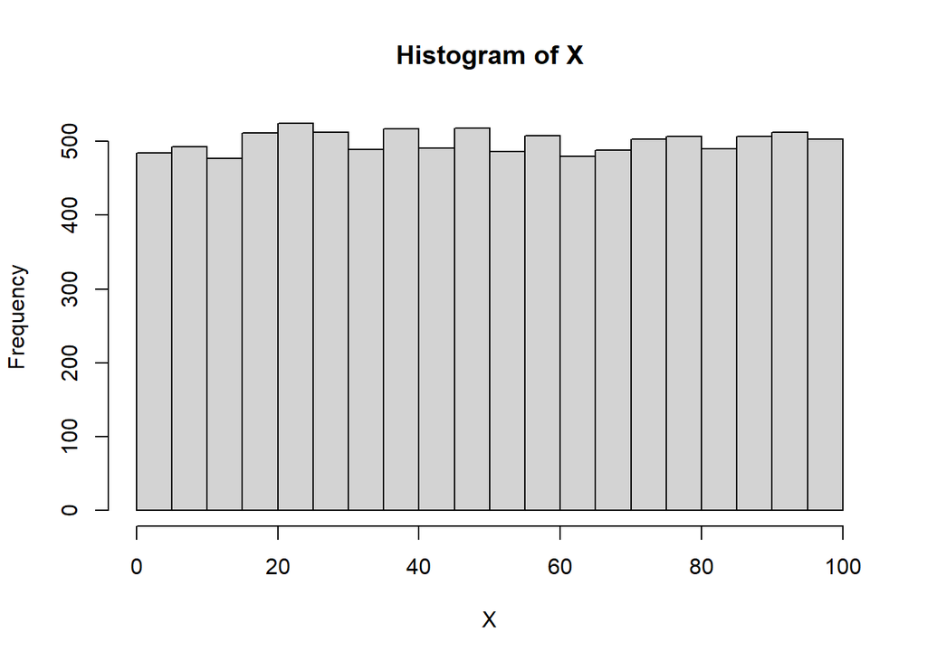

```r
m = 100
n = 10000
U = runif(n) #use same set of U to compare plot
X = Y = vector(length = n)
# Standard way
for (i in 1:n)
{
  for (j in 1:m)
  {
    if (U[i] > (j-1)/m && U[i] <= j/m)
    {
      X[i] = j
      break
    }
  }
}
hist(X)
```

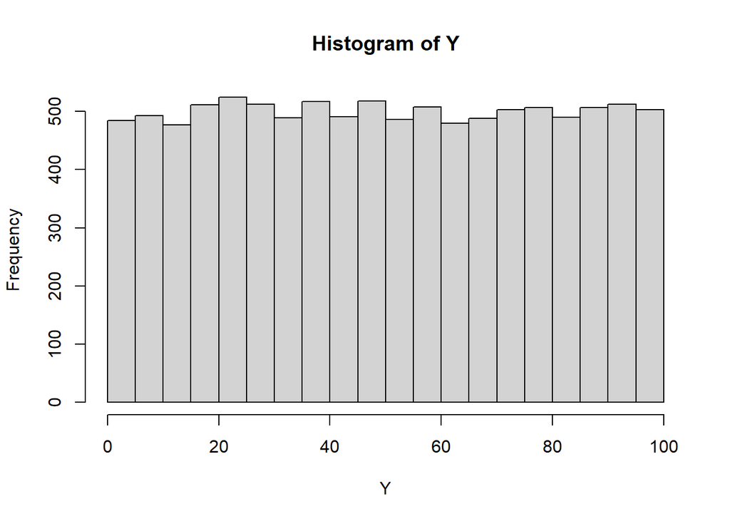

```r
# Non-standard way
for (i in 1:n)
{
  Y[i] = ceiling(U[i]*m)
}
hist(Y) #same shape as X's plot
```